# Project Overview

In 2000, Enron was one of the largest companies in the United States. By 2002, it had collapsed into bankruptcy due to widespread corporate fraud. In the resulting Federal investigation, a significant amount of typically confidential information entered into the public record, including tens of thousands of emails and detailed financial data for top executives.

In this project, you will play detective, and put your new skills to use by building a person of interest identifier based on financial and email data made public as a result of the Enron scandal. To assist you in your detective work, we've combined this data with a hand-generated list of persons of interest in the fraud case, which means individuals who were indicted, reached a settlement or plea deal with the government, or testified in exchange for prosecution immunity.

```python
# Changing the working directory to load all our files.
import os
os.chdir('C:/udacity-git-course/Machine Learning/ud120-projects-master/final_project')
```

```python
# Loading all relevant module, files

import sys
import pickle
sys.path.append("../tools/")

from feature_format import featureFormat, targetFeatureSplit
from tester import dump_classifier_and_data
import matplotlib.pyplot as plt



### Task 1: Select what features you'll use.
### features_list is a list of strings, each of which is a feature name.
### The first feature must be "poi".

financial_features = ['salary', 'deferral_payments', 'total_payments', 'loan_advances', 'bonus',
                      'restricted_stock_deferred', 'deferred_income', 'total_stock_value', 'expenses',
                      'exercised_stock_options', 'other', 'long_term_incentive', 'restricted_stock',
                      'director_fees']

email_features = ['to_messages', 'from_poi_to_this_person', 'from_messages',
                  'from_this_person_to_poi', 'shared_receipt_with_poi']

POI_label = ['poi']


total_features_list = POI_label + financial_features + email_features


features_list = []
print(total_features_list)    #Check if all the features has been added
print("\t")
```

```
['poi', 'salary', 'deferral_payments', 'total_payments', 'loan_advances', 'bonus', 'restricted_stock_deferred', 'deferred_income', 'total_stock_value', 'expenses', 'exercised_stock_options', 'other', 'long_term_incentive', 'restricted_stock', 'director_fees', 'to_messages', 'from_poi_to_this_person'…
```

```python
### Load the dictionary containing the dataset
with open("final_project_dataset.pkl", "r") as data_file:
    data_dict = pickle.load(data_file)

import random
name, assets = random.choice(list(data_dict.items()))
```

## Enron Data

Firstly let's find the number of people we are dealing with.

```python
print ("There are {0} executives in Enron Dataset.".format(len(data_dict.keys())) )
print("\t")
```

```
There are 146 executives in Enron Dataset.
```

## Outlier Detection

Now let look at the distribution of two features to get an idea of how it looks.

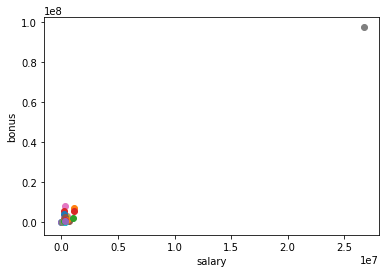

```python
features = ["salary", "bonus"]
data = featureFormat(data_dict, features)


for point in data:
    salary = point[0]
    bonus = point[1]
    plt.scatter( salary, bonus )

plt.xlabel("salary")
plt.ylabel("bonus")
plt.show()
```

So I can see there is an outlier which has huge bonus and salary. Upon some investigation i found that this is a number for total salary and bonus.

As this is not sensible information for our analysis I remove it manually.

```
[('SKILLING JEFFREY K', 1111258), ('LAY KENNETH L', 1072321), ('FREVERT MARK A', 1060932), ('PICKERING MARK R', 655037), ('WHALLEY LAWRENCE G', 510364)]
```

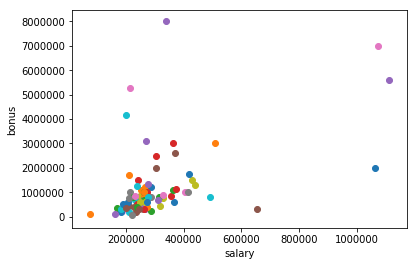

```python
### Task 2: Remove outliers
data_dict.pop('TOTAL',0)
data_dict.pop('The Travel Agency In the Park',0)

data_dict_list = []

for key in data_dict:
    val = data_dict[key]['salary']
    if val == 'NaN':
        continue
    data_dict_list.append((key, int(val)))



# Sorting the data_dict list and storing the top 5 executives with highest salary and bonus
data_dict_list_final = (sorted(data_dict_list,key=lambda x:x[1],reverse=True)[:5])
### print top 5 salaries
print data_dict_list_final


# Again checking the distribution of the two selected features
features = ["salary", "bonus"]
data = featureFormat(data_dict, features, remove_any_zeroes=True)

### your code below

for point in data:
    salary = point[0]
    bonus = point[1]
    plt.scatter( salary, bonus )

plt.xlabel("salary")
plt.ylabel("bonus")
plt.show()
```

So the above is the distribution of salary vs bonus and although it seems we have some outliers in it, but they are important persons of interest and we can't neglect them for our analysis.

## Creating new features

```python
### Task 3: Create new feature(s)
### Store to my_dataset for easy export below.

def add_features(data_dict):
    """
    Given the data dictionary of people with features, adds some features to
    """
    for name in data_dict:

        # Add ratio of POI messages to total.
        try:
            total_messages = data_dict[name]['from_messages'] + data_dict[name]['to_messages']
            poi_related_messages = data_dict[name]["from_poi_to_this_person"] +\
                                    data_dict[name]["from_this_person_to_poi"] +\
                                    data_dict[name]["shared_receipt_with_poi"]
            poi_ratio = 1.* poi_related_messages / total_messages
            data_dict[name]['poi_ratio_messages'] = poi_ratio
            data_dict[name]['poi_ratio_messages_squared'] = poi_ratio ** 2
        except:
            data_dict[name]['poi_ratio_messages'] = 'NaN'

        # Add ratio of restricted stock value to total stock value.
        try:

            restricted_stock_ratio = float(data_dict[name]['restricted_stock']) / float(data_dict[name]['total_stock_value'])
            data_dict[name]['restricted_stock_ratio'] = round(restricted_stock_ratio, 2)
        except:
            data_dict[name]['restricted_stock_ratio'] = 'NaN'

        # Add ratio of money spent.
        try:
            money_ratio = float(data_dict[name]['expenses'])/float(data_dict[name]['salary'])
            data_dict[name]['money_ratio'] = round(money_ratio, 2)
        except:
            data_dict[name]['money_ratio'] = 'NaN'

    # print "finished"

    return data_dict
```

## Checking NaN values

```python
import operator
from pprint import pprint


## Check the % of NaNs for each feature - for general understanding.
def check_nan_features(dict):
    """
    Checks the percentage of NaNs for each feature in the data.
    Args:
        dict: data dictionary
    Returns: dict of all features with the percentage of NaNs
    """
    final = {}
    ftrs_list = dict[dict.keys()[0]].keys()
    cnt = float(len(data_dict))
    for i in ftrs_list:
        n = 0.0
        for k, v in dict.items():
            if v[i] == 'NaN':
                n += 1.0
        final[i] = (n / cnt) * 100
    return final

nans_check = check_nan_features(data_dict)
sorted_nans_check = sorted(nans_check.items(), key=operator.itemgetter(1), reverse = True)
print '\nNaN Checks for Each Feature'
pprint (sorted_nans_check)
```

```
NaN Checks for Each Feature
[('loan_advances', 97.93103448275862),
 ('director_fees', 88.96551724137932),
 ('restricted_stock_deferred', 88.27586206896552),
 ('deferral_payments', 73.79310344827587),
 ('deferred_income', 66.89655172413794),
 ('long_term_incentive', 55.172413793103445),
 ('bonus', 44.13793103448276),
 ('to_messages', 40.689655172413794),
 ('shared_receipt_with_poi', 40.689655172413794),
 ('from_messages', 40.689655172413794),
 ('from_poi_to_this_person', 40.689655172413794),
 ('from_this_person_to_poi', 40.689655172413794),
 ('other', 36.55172413793103),
 ('salary', 35.172413793103445),
 ('expenses', 35.172413793103445),
 ('exercised_stock_options', 30.344827586206897),
 ('restricted_stock', 24.82758620689655),
 ('email_address', 23.448275862068964),
 ('total_payments', 14.482758620689657),
 ('total_stock_value', 13.793103448275861),
 ('poi', 0.0)]
```

```python
my_dataset = add_features(data_dict)
```

Updating features_list with relevant features

```python
unwanted_features = ['restricted_stock_deferred', 'director_fees', 'loan_advances']

features_list = [feature for feature in total_features_list if feature not in unwanted_features]

print features_list
```

```
['poi', 'salary', 'deferral_payments', 'total_payments', 'bonus', 'deferred_income', 'total_stock_value', 'expenses', 'exercised_stock_options', 'other', 'long_term_incentive', 'restricted_stock', 'to_messages', 'from_poi_to_this_person', 'from_messages', 'from_this_person_to_poi', 'shared_receipt_w…
```

```python
#name, assets_new = random.choice(list(my_dataset.items()))

#print(name)
#print(assets_new)
```

```python
### Extract features and labels from dataset for local testing

print "All features"
print total_features_list
data = featureFormat(my_dataset, total_features_list, sort_keys = True)
labels, features = targetFeatureSplit(data)


print("\t")

from sklearn.feature_selection import SelectKBest, f_classif
#kbest = SelectKBest()
kbest = SelectKBest(k=10)
selected_features = kbest.fit_transform(features,labels)
features_selected=[total_features_list[i+1] for i in kbest.get_support(indices=True)]
print 'Features selected by SelectKBest:'
print features_selected
print "\t"

indices = kbest.get_support(True)
#print indices
#print kbest.scores_
print "Features and their Scores"

for index in indices:
    #print index+1
    print 'features: %s score: %f' % (total_features_list[index+1], kbest.scores_[index])



## At first i thought of selecting features via KBest but later i used pipeline to get the
## desired result so no need of this step
```

```
All features
['poi', 'salary', 'deferral_payments', 'total_payments', 'loan_advances', 'bonus', 'restricted_stock_deferred', 'deferred_income', 'total_stock_value', 'expenses', 'exercised_stock_options', 'other', 'long_term_incentive', 'restricted_stock', 'director_fees', 'to_messages', 'from_poi_to_this_person'…

Features selected by SelectKBest:
['salary', 'total_payments', 'loan_advances', 'bonus', 'deferred_income', 'total_stock_value', 'exercised_stock_options', 'long_term_incentive', 'restricted_stock', 'shared_receipt_with_poi']

Features and their Scores
features: salary score: 18.575703
features: total_payments score: 8.866722
features: loan_advances score: 7.242730
features: bonus score: 21.060002
features: deferred_income score: 11.595548
features: total_stock_value score: 24.467654
features: exercised_stock_options score: 25.097542
features: long_term_incentive score: 10.072455
features: restricted_stock score: 9.346701
features: shared_receipt_with_poi score: 8.746486
```

## Data Preprocessing

Now lets bring the data to same scale before further passing it to the classifiers.

```python
from sklearn import preprocessing
scaler = preprocessing.MinMaxScaler()
features = scaler.fit_transform(features)
```